# Week 01 Assignment epileptic seizure

As a Data Scientist you often have lots of data at our disposal. Unfortunately, data from real-life cases is often not nicely structured. We need to manipulate the unstructured and/or messy data into a structured or clean form. We need to drop rows and columns because they are not needed for the analysis or because we cannot use them in case of too many missing values. Maybe we need to relabel columns or reformat characters into numerical values. Or we need to combine data from several sources. Cleaning and manipulating data into a structured form is called data preparation. In this week we will practice the cleaning and manipulation of EEG data in order to conduct graphical and statistical analysis. We will use tools often used by data scientists; `python`, `numpy`, `pandas` and `bokeh`. You will learn about data wrangling with `pandas` and `numpy` and you will learn to visualize with `bokeh`. Concretely, you will preprocess the brain EEG data in an appropiate format in order to conduct statistical and visual analysis.

Keywords: data loading, data inspection, data exploration, reshape data, data cleaning, timeseries, pandas, visualization, statistics, tidy table

More to read:

- Andrzejak RG, Lehnertz K, Rieke C, Mormann F, David P, Elger CE (2001) Indications of nonlinear deterministic and finite dimensional structures in time series of brain electrical activity: Dependence on recording region and brain state, Phys. Rev. E, 64, 061907

More about pandas and git:

- https://fennaf.gitbook.io/bfvm22prog1/
- https://opensourceuom.gitlab.io/blog/post_files/2022-02-23/git-essentials-cheatsheet.pdf
- https://nbviewer.org/github/ageron/handson-ml/blob/master/tools_pandas.ipynb
- https://github.com/fenna/BFVM22PROG1/blob/main/exercises/quiz_pandas.ipynb

Learning objectives

- Understand the concepts and benefits of vectorized manipulation
- Understand the concepts of the visualization tool bokeh
- Read, inspect, clean, and reshape a file into a tabular tidy format
- Perform visual and statistical analysis for time series data
- Maintain development environment
- Apply coding standards and FAIR principles

By the end of this week the student can:

- load a tabular dataset and and rename the column names
- split a text column into two columns in Pandas DataFrame
- inspect the dataset for quality and metadata information
- reshape the dataset into a format suitable for visual and statistical analysis
- perform visual analysis
- perform statistical analysis

Please add your own topics you want to learn here: https://padlet.com/ffeenstra1/y97afib6ovx96lr9

A final plot will look like this:

[figure not shown]

The assignment consists of 6 parts:

- part 1: load the data
  - Exercise 1.1
- part 2: prepare for inspection
  - Exercise 2.1
- part 3: inspect the data
  - Exercise 3.1
- part 4: reshape the data
  - Exercise 4.1
  - Exercise 4.3
- part 5: visualize the data
  - Exercise 5.1
- part 6: statistical analysis
  - Exercise 6.1

Part 1 and 5 are mandatory, part 6 is optional (bonus) Mind you that you cannot copy code without referencing the code. If you copy code you need to be able to explain your code verbally and you will not get the full score.

## The Data

You will use a dataset called `eeg_data.csv`. This is a preprocessed dataset. The original dataset from the reference consists of 5 different folders, each with 100 files, with each file representing a single subject/person. Each file is a recording of brain activity for around 23 seconds. Each data point is the value of the EEG recording at a different point in time. There are in total 500 patients with each has 4097 datapoints.

The originial data was shuffled into 23 chunks per patient, each chunk contains 178 data points. The first column is an identifier with the chunk number (X1 ..X23) and the Patient number (for example V1.791) The EEG recordings are X1, X2, ..., X178. The last column represents the label y {1,2,3,4,5}

5 - eyes open, means when they were recording the EEG signal of the brain the patient had their eyes open

4 - eyes closed, means when they were recording the EEG signal the patient had their eyes closed

3 - Yes they identify where the region of the tumor was in the brain and recording the EEG activity from the healthy brain area

2 - They recorder the EEG from the area where the tumor was located

1 - Recording of seizure activity

All subjects falling in classes 2, 3, 4, and 5 are subjects who did not have epileptic seizure. Only subjects in class 1 have epileptic seizure.

Source: Andrzejak RG, Lehnertz K, Rieke C, Mormann F, David P, Elger CE (2001) Indications of nonlinear deterministic and finite dimensional structures in time series of brain electrical activity: Dependence on recording region and brain state, Phys. Rev. E, 64, 061907

Preferably we read the data not with a hard coded data path but using a config file. See https://fennaf.gitbook.io/bfvm22prog1/data-processing/configuration-files/yaml

Run the cell below to load in the packages.

```python
import yaml
import pandas as pd
import numpy as np
from bokeh.io import output_notebook
output_notebook()
```

Loading BokehJS ...

## Part 1: Load the data

Instructions: Load the data and rename the unnamed column containing the identifier with the chunck number and the patientID into the column `ID`

**Hints**

- pandas.read_csv() method can be used to read a csv file
- pandas.DataFrame.head() method is often used to inspect the dataframe
- pandas.DataFrame.rename() method can be used to rename columns

### 1.1 Code your solution

```python
with open('config.yaml', 'r') as stream:
    config = (yaml.safe_load(stream))
    file = config['file_assignemnt_1']

print(file)

df = pd.read_csv(file)
df = df.rename(columns={'Unnamed: 0':'ID'})
df.head()
```

```
/data/datasets/Programming1/eeg_data.csv
```

|  | ID | X1 | X2 | X3 | X4 | X5 | X6 | X7 | X8 | X9 | ... | X170 | X171 | X172 | X173 | X174 | X175 | X176 | X177 | X178 | y |
| --- | --- | --- | --- | --- | --- | --- | --- | --- | --- | --- | --- | --- | --- | --- | --- | --- | --- | --- | --- | --- | --- |
| 0 | X21.V1.791 | 135 | 190 | 229 | 223 | 192 | 125 | 55 | -9 | -33 | ... | -17 | -15 | -31 | -77 | -103 | -127 | -116 | -83 | -51 | 4 |
| 1 | X15.V1.924 | 386 | 382 | 356 | 331 | 320 | 315 | 307 | 272 | 244 | ... | 164 | 150 | 146 | 152 | 157 | 156 | 154 | 143 | 129 | 1 |
| 2 | X8.V1.1 | -32 | -39 | -47 | -37 | -32 | -36 | -57 | -73 | -85 | ... | 57 | 64 | 48 | 19 | -12 | -30 | -35 | -35 | -36 | 5 |
| 3 | X16.V1.60 | -105 | -101 | -96 | -92 | -89 | -95 | -102 | -100 | -87 | ... | -82 | -81 | -80 | -77 | -85 | -77 | -72 | -69 | -65 | 5 |
| 4 | X20.V1.54 | -9 | -65 | -98 | -102 | -78 | -48 | -16 | 0 | -21 | ... | 4 | 2 | -12 | -32 | -41 | -65 | -83 | -89 | -73 | 5 |

5 rows × 180 columns

### 1.2 Test your solution

```python
#do not modify this cell, run cell to test your code
try:
    df.info()
except:
    print("df not properly loaded")
```

```
<class 'pandas.core.frame.DataFrame'>
RangeIndex: 11500 entries, 0 to 11499
Columns: 180 entries, ID to y
dtypes: int64(179), object(1)
memory usage: 15.8+ MB
```

#### Expected outcome:

<class 'pandas.core.frame.DataFrame'> RangeIndex: 11500 entries, 0 to 11499 Columns: 180 entries, ID to y dtypes: int64(179), object(1) memory usage: 15.8+ MB

The dataset should have 11500 entries (500patients x 23 rows per patient) and 180 columns (178 recordings, an identifier and the class variable y)

## Part 2: Prepare for inspection

Although the number of records suggest that there should be 500 patients with 23 record each we would like to check this. Furthermore we do not know whether the y label is the same for each patient. We also do not know whether there are missing values. In order to answer the questions above it is more convient to split up the identifier containing a combination of chunck number and patient ID into two separate columns. After that we can do some inspections.

Instructions:

- change the `ID` column into two separate columns `idx` and `patient_id`
- change the column `idx` into a number (you need to stripe the X first)
- remove the `ID` column from the DataFrame

**Hints**

- pandas.DataFrame.str.split() method can be used to split
- pandas.DataFrame.astype(int) method can be used to typecast to a number
- pandas.DataFrame.drop() method can be used to drop a column

### 2.1 Code your solution

```python
df[['idx', 'patient_id']] = df['ID'].str.split('.', 1, expand=True)
df['idx'] = df['idx'].str.strip('X').astype(int)
df = df.drop('ID', axis=1)
df.head(5)
```

|  | X1 | X2 | X3 | X4 | X5 | X6 | X7 | X8 | X9 | X10 | ... | X172 | X173 | X174 | X175 | X176 | X177 | X178 | y | idx | patient_id |
| --- | --- | --- | --- | --- | --- | --- | --- | --- | --- | --- | --- | --- | --- | --- | --- | --- | --- | --- | --- | --- | --- |
| 0 | 135 | 190 | 229 | 223 | 192 | 125 | 55 | -9 | -33 | -38 | ... | -31 | -77 | -103 | -127 | -116 | -83 | -51 | 4 | 21 | V1.791 |
| 1 | 386 | 382 | 356 | 331 | 320 | 315 | 307 | 272 | 244 | 232 | ... | 146 | 152 | 157 | 156 | 154 | 143 | 129 | 1 | 15 | V1.924 |
| 2 | -32 | -39 | -47 | -37 | -32 | -36 | -57 | -73 | -85 | -94 | ... | 48 | 19 | -12 | -30 | -35 | -35 | -36 | 5 | 8 | V1.1 |
| 3 | -105 | -101 | -96 | -92 | -89 | -95 | -102 | -100 | -87 | -79 | ... | -80 | -77 | -85 | -77 | -72 | -69 | -65 | 5 | 16 | V1.60 |
| 4 | -9 | -65 | -98 | -102 | -78 | -48 | -16 | 0 | -21 | -59 | ... | -12 | -32 | -41 | -65 | -83 | -89 | -73 | 5 | 20 | V1.54 |

5 rows × 181 columns

### 2.2 Test your solution

```python
#do not modify this cell, run cell to test your code
try:
    print(df.dtypes)
except:
    print("df not properly loaded")
```

```
X1             int64
X2             int64
X3             int64
X4             int64
X5             int64
               ...
X177           int64
X178           int64
y              int64
idx            int64
patient_id    object
Length: 181, dtype: object
```

#### expected outcome:

X1 int64 X2 int64 X3 int64 X4 int64 X5 int64 ... X177 int64 X178 int64 y int64 idx int64 patient_id object Length: 181, dtype: object

## Part 3: Inspect the data

Now that we prepared the data we are going to inspect the data to get more familiar with the data. You are required to do the following

- inspect how many patients are in the dataset (should be 500 different)
- inspect if patient V1.924 has 23 records
- check if a patient has more than 1 Y value
- check for how many patients are there per level
- check if there are missing values

The code for the inspection of the chunk numbers is given.

**Hints**

- pandas.DataFrame.groupby()
- (df[df['columnname'] == value])
- if you sum the expression ['y'].min() == ['y'].max() when grouped by patient it should return 500

### 3.1 Code your solution

```python
# should have 23 chunck numbers
len(pd.DataFrame(df.groupby('idx')))
```

```
23
```

```python
#- number of patients
print(f"No of patients: {len(df['patient_id'].unique())}")

#- inspect if patient V1.924 has 23 records
print(f"Number of records for patient V1.924: {len(df[df['patient_id']== 'V1.924'])}")

#- check if a patient has more than 1 Y value
y_variance = df.groupby('patient_id')['y'].min() - df.groupby('patient_id')['y'].max()
print(f"Patients with more than one Y value: {len(y_variance[y_variance != 0])}")

#- check for how many patients are there per level
print('Number of patients per level:')
print(df.groupby('y')['patient_id'].unique().apply(len))

#- check if there are missing values
print(f'Number of missing values: {len(df.isnull().sum()[df.isnull().sum() != 0])}')
```

```
No of patients: 500
Number of records for patient V1.924: 23
Patients with more than one Y value: 0
Number of patients per level:
y
1    100
2    100
3    100
4    100
5    100
Name: patient_id, dtype: int64
Number of missing values: 0
```

## Part 4: Reshape the data

We would like to plot the patient data. Therefore we would need to reshape the data. For plotting purpose the data of the 23 chunks need to be ordered by patient and chunk number first. And then we need to get the X1..X178 data (a matrix with shape 23, 178) to be reshaped to one array of 178 * 23 = 4094 datapoints. (shape 1, 4094). The 4094 datapoint array is the EEG signal data of a particular patient to be plotted on the y-axis. On the x-axis we simply can create a sequence from 1 to 4094.

Instructions:

- set the index to `patient_id` and `idx`
- sort the index
- create a timesequence from 1 to 4094
- finish the code to select a patient
- finish the code to get the data of a patient and reshape it into an one dimensional array

**Hints**

- df.set_index
- df.sort_index
- use np.arange to create the sequence and use tolist to transfer it to a list
- check pandas.DataFrame.iloc and slicing options for selecting a subset of the data
- with numpy.reshape you can reshape a matrix

### 4.1 Code your solution

```python
#set index
df = df.set_index(['patient_id','idx'])
```

```python
#sort index
df = df.sort_index()
timeseq = np.arange(1,4095) #change this, should return a list with values 1..4094
df.head(2)
```

| patient_id | idx | X1 | X2 | X3 | X4 | X5 | X6 | X7 | X8 | X9 | X10 | ... | X170 | X171 | X172 | X173 | X174 | X175 | X176 | X177 | X178 | y |
| --- | --- | --- | --- | --- | --- | --- | --- | --- | --- | --- | --- | --- | --- | --- | --- | --- | --- | --- | --- | --- | --- | --- |
| V1 | 1 | 12 | 22 | 35 | 45 | 69 | 74 | 79 | 78 | 66 | 43 | ... | -18 | -32 | -47 | -53 | -48 | -40 | -17 | -23 | -32 | 5 |
|  | 2 | -41 | -50 | -53 | -49 | -35 | -28 | -15 | -2 | 14 | 18 | ... | 34 | 22 | 4 | -18 | -31 | -27 | -26 | -21 | -30 | 5 |

2 rows × 179 columns

### 4.2 Test your solution

```python
#check outcome df and timeseq, do not modify this cell, run to test
print(df.head(2))
print(f'the length of timeseq [{np.array(timeseq).min()}..{np.array(timeseq).max()}] is {len(timeseq)}')
```

```
                X1  X2  X3  X4  X5  X6  X7  X8  X9  X10  ...  X170  X171  \
patient_id idx                                           ...
V1         1    12  22  35  45  69  74  79  78  66   43  ...   -18   -32
           2   -41 -50 -53 -49 -35 -28 -15  -2  14   18  ...    34    22

                X172  X173  X174  X175  X176  X177  X178  y
patient_id idx
V1         1     -47   -53   -48   -40   -17   -23   -32  5
           2       4   -18   -31   -27   -26   -21   -30  5

[2 rows x 179 columns]
the length of timeseq [1..4094] is 4094
```

#### expected outcome:

X1 X2 X3 X4 X5 X6 X7 X8 X9 X10 ... X170 X171 \ patient_id idx ... V1 1 12 22 35 45 69 74 79 78 66 43 ... -18 -32 2 -41 -50 -53 -49 -35 -28 -15 -2 14 18 ... 34 22 X172 X173 X174 X175 X176 X177 X178 y patient_id idx V1 1 -47 -53 -48 -40 -17 -23 -32 5 2 4 -18 -31 -27 -26 -21 -30 5 [2 rows x 179 columns] the length of timeseq [1..4094] is 4094

Now that we reorganized the patients we could use the new dataframe to select a patient, load the values in an numpy matrix and reshape that to a one dimensional array. To do such complete the code below

### 4.3 Code your solution

```python
#get the data of one patient
def get_patient(df, patient):
    ##########################
    dfpat = df.loc[patient] # change this line to select only the records from the particular patient
    #########################
    return dfpat.sort_index()


#fetch the values part and put in numpy array
def get_values(df):
    ###############################
    X = np.array(df.drop('y', axis=1)) # change this line to load value columns and the rows of the patient
    ###############################
    n = int(len(df) / 23)
    X = X.reshape(n, 4094)
    return X
```

### 4.4 Test your solution

```python
#check outcome of array, do not modify this cell, run to test
test_patient = get_values(get_patient(df,'V1.334'))[0]
print(f'the length of patient V1.334 array {test_patient} = {len(test_patient)}')
```

```
the length of patient V1.334 array [ -18  -55 -126 ... -210 -222 -224] = 4094
```

### expected outcome

the length of patient V1.334 array [ -18 -55 -126 ... -210 -222 -224] = 4094

## Part 5: Plot the data

In this part we will first select some patients per class level in the function `get_data(level)`. Then we are going to plot two plots per level using bokeh. Your job is to finish the code of the bokeh plot. For each patient eeg signal should be plotted on the y-axis given the timesequence on the x-axis

```python
#code to select some patients per level, do not modify this cell, run this cell
#it is allowed though to add some print statements in order to understand what is happening
def get_data(level):
    df_level = df[df['y']==level]
    s = df_level.index.unique().tolist()
    patients = np.array(sorted(set([x[0] for x in s]))).tolist()
    return list(patients)[3:5]

p1 = get_data(1)
p2 = get_data(2)
p3 = get_data(3)
p4 = get_data(4)
p5 = get_data(5)
```

### 5.1 Code your solution

```python
from bokeh.plotting import figure, show
from bokeh.layouts import gridplot
from bokeh.models import Range1d


def make_plot(title, y, pat_values, timeseq, color):
    p = figure(title=title, background_fill_color="#fafafa")
    p.y_range=Range1d(-1500, 1500)

    ###########################################
    p.line(timeseq,pat_values, color=color) # CHANGE THIS LINE
    ###########################################

    p.xaxis.axis_label = 'time'
    p.yaxis.axis_label = 'signal'
    p.grid.grid_line_color="white"
    return p


def make_plot_array(g, pa, y):
    d = {1:'seizure', 2:'tumor location', 3:'non-tumor location', 4:'eyes closed', 5:'eyes open'}
    for i in pa:
        v = get_values(get_patient(df,i))[0]
        p = make_plot(title = f'brain EEG for patient {i} {d[y]}', y=y, pat_values=v, timeseq=timeseq, color='black')
        g.append(p)
    return g

g = []
g = make_plot_array(g, p1, 1)
g = make_plot_array(g, p2, 2)
g = make_plot_array(g, p3, 3)
g = make_plot_array(g, p4, 4)
g = make_plot_array(g, p5, 5)

show(gridplot(g, ncols=2, width=450, height=300))
```

## Part 6: Statistical analysis (bonus points)

From the graphical analysis is seems that there is significant difference between level 1 and the other levels. We can use `pandas.DataFrame.melt` to prepare the data for statistical analysis. Your job is to give statistical evidence of a significant difference see also [gitbook example](https://fennaf.gitbook.io/bfvm19prog1/data-wrangling/reshape-with-melt)

### 6.1 Code your solution

```python
melt_y = df.melt(id_vars='y')
print('Y Level SD')
print(melt_y.groupby('y').std())
print('\nY Level mean')
print(melt_y.groupby('y').mean())
```

```
Y Level SD
        value
y
1  341.151718
2   90.354274
3   59.392194
4   70.685356
5   48.339153

Y Level mean
       value
y
1  -4.760684
2  -6.202807
3  -8.881236
4 -12.511610
5  -6.255845
```

```
''
```

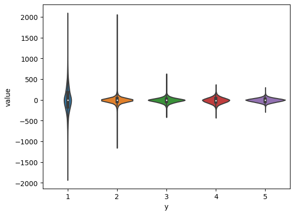

```python
import seaborn as sns
sns.violinplot(x=melt_y['y'], y=melt_y['value'])
;
```

The violin plot above shows that there's way more sperad in yhe y1 group compared to the other groups. To test the significance of this difference I've decided to use a two sample t-test but honestly am not sure if this is the right way. We haven't covered that yet in statistics.

```python
def DS_2sample_ttest_means(y1, y2, equal_var=False, alternative='two-sided', alpha=0.05):
    """
    *
    Function DS_2sample_ttest_means(y1, y2, equal_var=False, alternative='two-sided', alpha=0.05)

       This function performs a 2-sample (Welch's) t-test (Null Hypothesis Significance Test)
       in the spirit of R, testing 2 averages with *unknown* standard deviation.
       The function also evaluates the effect size (Cohen's d).

    Requires:          -

    Usage:             DS_2sample_ttest_means(y1, y2,
                            alternative=['two-sided']/'less'/'greater',
                            equal_var=[False]/True, alpha = 0.05)

                         alternative = 'two-sided' [default]  H1: mu_1 != mu_2
                                       'less'                 H1: mu_1 < mu_2
                                       'greater'              H1: mu_1 > mu_2
                         equal_var = False                    perform Welch t-test
                                     True                     perform 2-sample t-test
                         alpha:   significance level of test [default: 0.05]

    Return:            t, p-value, t.crit.L, t.crit.R  [ + print interpretable output to stdout ]
                       where t.crit.L and t.crit.R are the lower and upper critical values,
                       t is the test statistic and p-value is the p-value of the test.

    Author:            M.E.F. Apol
    Date:              2022-01-28, rev. 2022_08_26
    Validation:
    """

    from scipy.stats import ttest_ind
    from scipy.stats import t as t_distr
    import numpy as np

    t, p_samp = ttest_ind(y1, y2, equal_var = equal_var)
    y_av_1 = np.mean(y1)
    y_av_2 = np.mean(y2)
    n_1 = len(y1)
    n_2 = len(y2)
    s2_1 = np.var(y1, ddof=1)
    s2_2 = np.var(y2, ddof=1)
    print(80*'-')
    if equal_var == True:
        print('2-sample t-test for 2 means:')
        print('     assuming Normal(mu.1, sigma2) data for dataset 1')
        print('     assuming Normal(mu.2, sigma2) data for dataset 2')
        df = n_1 + n_2 - 2
    else:
        print('Welch t-test for 2 means:')
        df = (s2_1/n_1 + s2_2/n_2)**2 / ( 1/(n_1-1)*(s2_1/n_1)**2 + 1/(n_2-1)*(s2_2/n_2)**2 )
        print('     assuming Normal(mu.1, sigma2.1) data for dataset 1')
        print('     assuming Normal(mu.2, sigma2.2) data for dataset 2')
    print('y.av.1 = {:.3g}, y.av.2 = {:.3g}, s2.1 = {:.3g}, s2.2 = {:.3g}, n.1 = {:d}, n.2 = {:d}, alpha = {:.3g}'.format(y_av_1, y_av_2, s2_1, s2_2, n_1, n_2, alpha))
    print('H0: mu.1  = mu.2')
    if alternative == 'two-sided':
        print('H1: mu.1 != mu.2')
        p_value = p_samp
        t_crit_L = t_distr.ppf(alpha/2, df)
        t_crit_R = t_distr.ppf(1-alpha/2, df)
    elif alternative == 'less':
        print('H1: mu.1  < mu.2')
        if t <= 0:
            p_value = p_samp/2
        else:
            p_value = 1 - p_samp/2
        t_crit_L = t_distr.ppf(alpha, df)
        t_crit_R = float('inf')
    elif alternative == 'greater':
        print('H1: mu.1  > mu.2')
        if t >= 0:
            p_value = p_samp/2
        else:
            p_value = 1 - p_samp/2
        t_crit_L = float('-inf')
        t_crit_R = t_distr.ppf(1-alpha, df)
    else:
        print('Wrong alternative hypothesis chosen!')
        print(80*'-' + '\n')
        t, p_value, t_crit_L, t_crit_R = np.nan, np.nan, np.nan, np.nan
        return(t, p_value, t_crit_L, t_crit_R)

    # Effect size (Cohen's d.av):
    d_av = t * np.sqrt(1/n_1 + 1/n_2)
    print('t = {:.4g}, p-value = {:.4g}, t.crit.L = {:.4g}, t.crit.R = {:.4g}, df = {:.4g}'.format(t, p_value, t_crit_L, t_crit_R, df))
    print('Effect size: d.av = {:.3g}; benchmarks |d.av|: 0.2 = small, 0.5 = medium, 0.8 = large'.format(d_av))
    print(80*'-' + '\n')
    return(t, p_value, t_crit_L, t_crit_R)
```

```python
y1 = melt_y[melt_y['y'] == 1]
for i in range(2,6):
    yi = melt_y[melt_y['y'] == i]
    print(f"Comparison between Y1 and Y{i}")
    DS_2sample_ttest_means(y1=y1['value'], y2=yi['value'])
```

```
Comparison between Y1 and Y2
--------------------------------------------------------------------------------
Welch t-test for 2 means:
     assuming Normal(mu.1, sigma2.1) data for dataset 1
     assuming Normal(mu.2, sigma2.2) data for dataset 2
y.av.1 = -4.76, y.av.2 = -6.2, s2.1 = 1.16e+05, s2.2 = 8.16e+03, n.1 = 409400, n.2 = 409400, alpha = 0.05
H0: mu.1  = mu.2
H1: mu.1 != mu.2
t = 2.615, p-value = 0.008933, t.crit.L = -1.96, t.crit.R = 1.96, df = 4.666e+05
Effect size: d.av = 0.00578; benchmarks |d.av|: 0.2 = small, 0.5 = medium, 0.8 = large
--------------------------------------------------------------------------------

Comparison between Y1 and Y3
--------------------------------------------------------------------------------
Welch t-test for 2 means:
     assuming Normal(mu.1, sigma2.1) data for dataset 1
     assuming Normal(mu.2, sigma2.2) data for dataset 2
y.av.1 = -4.76, y.av.2 = -8.88, s2.1 = 1.16e+05, s2.2 = 3.53e+03, n.1 = 409400, n.2 = 409400, alpha = 0.05
H0: mu.1  = mu.2
H1: mu.1 != mu.2
t = 7.614, p-value = 2.668e-14, t.crit.L = -1.96, t.crit.R = 1.96, df = 4.342e+05
Effect size: d.av = 0.0168; benchmarks |d.av|: 0.2 = small, 0.5 = medium, 0.8 = large
--------------------------------------------------------------------------------

Comparison between Y1 and Y4
--------------------------------------------------------------------------------
Welch t-test for 2 means:
     assuming Normal(mu.1, sigma2.1) data for dataset 1
     assuming Normal(mu.2, sigma2.2) data for dataset 2
y.av.1 = -4.76, y.av.2 = -12.5, s2.1 = 1.16e+05, s2.2 = 5e+03, n.1 = 409400, n.2 = 409400, alpha = 0.05
H0: mu.1  = mu.2
H1: mu.1 != mu.2
t = 14.23, p-value = 5.701e-46, t.crit.L = -1.96, t.crit.R = 1.96, df = 4.445e+05
Effect size: d.av = 0.0315; benchmarks |d.av|: 0.2 = small, 0.5 = medium, 0.8 = large
--------------------------------------------------------------------------------

Comparison between Y1 and Y5
--------------------------------------------------------------------------------
Welch t-test for 2 means:
     assuming Normal(mu.1, sigma2.1) data for dataset 1
     assuming Normal(mu.2, sigma2.2) data for dataset 2
y.av.1 = -4.76, y.av.2 = -6.26, s2.1 = 1.16e+05, s2.2 = 2.34e+03, n.1 = 409400, n.2 = 409400, alpha = 0.05
H0: mu.1  = mu.2
H1: mu.1 != mu.2
t = 2.777, p-value = 0.005495, t.crit.L = -1.96, t.crit.R = 1.96, df = 4.258e+05
Effect size: d.av = 0.00614; benchmarks |d.av|: 0.2 = small, 0.5 = medium, 0.8 = large
--------------------------------------------------------------------------------
```

The p-value between Y1 and all the other Y-levels is smaller than 0.05, meaning there's a significant difference between Y level 1 and all the other levels.